# Data modeling in R

Andrew W. Park & John M. Drake

## Introduction

This is the fourth in a series of five exercises that constitute *Training Module 1: Introduction to Scientific Programming*, taught through the IDEAS PhD program at the University of Georgia Odum School of Ecology in conjunction with the Center for the Ecology of Infectious Diseases.

This exercise explores methods for using modeling to shape our inquiry of data. It reaches back to previous modules that taught us about data manipulation, data visualization and functions.

```r
library(tidyverse)
library(magrittr)
```

```r
library(maptools)
library(GGally)
```

## Case study

We’re going to work with the Lyme disease/Climate/Demography data set that you previously assembled.

## Importing data

*Task 1: Using either `read_csv` (note: the underscore version, not `read.csv`) or `load`, import the data set you put together in the module on ‘Data wranglin in R’.

```r
# SOLUTION
load("get_LdPrismPop.Rda")
#or
# read_csv("LdPrismPop.csv")
```

## Using visualization to acqaint ourselves with our data

There’s not a one-size-fits-all approach for how best to visually inspect and summarize your data. It depends what kind of data we’re looking at - and you already learned some good ideas in the visualization module. For quantitative data, such as climate, demographic and disease case data, we might be interested in knowing the range of data, which kinds of values are rare and common, and whether data are correlated with each other.

One way to do this is all in one go is with the function `ggpairs`, part of the `GGally` package, which has a language that is based on ggplot. For a data frame `df` where you’re interested in numeric data columns `x`, `y`, and `z`, we load the GGally library and issue the command `ggpairs(df,columns=c("x","y","z"))`. This will make a 3x3 plot (because we have 3 columns: x, y and z). The main diagonals will display the density of the data (like a histogram, but continuous rather than binned). The lower triangle plots will show the correlation between each pair of data, and the upper triangle will report the correlation coefficient (a number between -1 and +1, where number close to +1 (-1) indicate a strong positive (negative) correlation and numbers close to 0 indicate weak or no association). Note that `ggpairs` doesn’t always display this way - it depends what kind of data you’re visualizing.

*Task 2: Use the `ggpairs` function to obtain a 4x4 summary plot of precipitation (prcp), average temperature (avtemp), population size (size), number of Lyme disease cases (cases).*

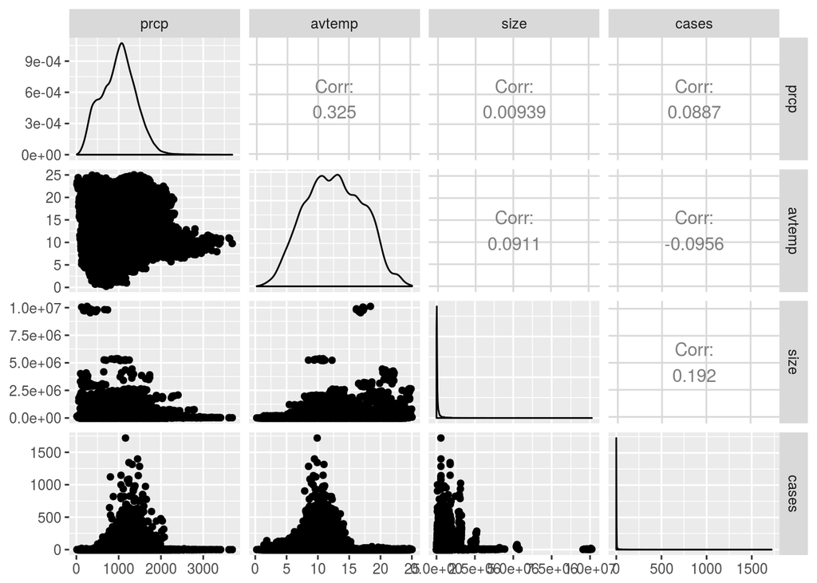

You’ll note from the density plots on the diagonals, that the data columns ‘size’ and ‘cases’ are very clumped, with many low values and a few large values. These may be easier to visualize by transforming to a logarithmic scale.

*Task 3: Create two new columns for log10(size) and log10(cases+1) and substitute these for the original size and cases supplied when you recreate the ggpairs plot. Why do we add 1 to the number of cases?*

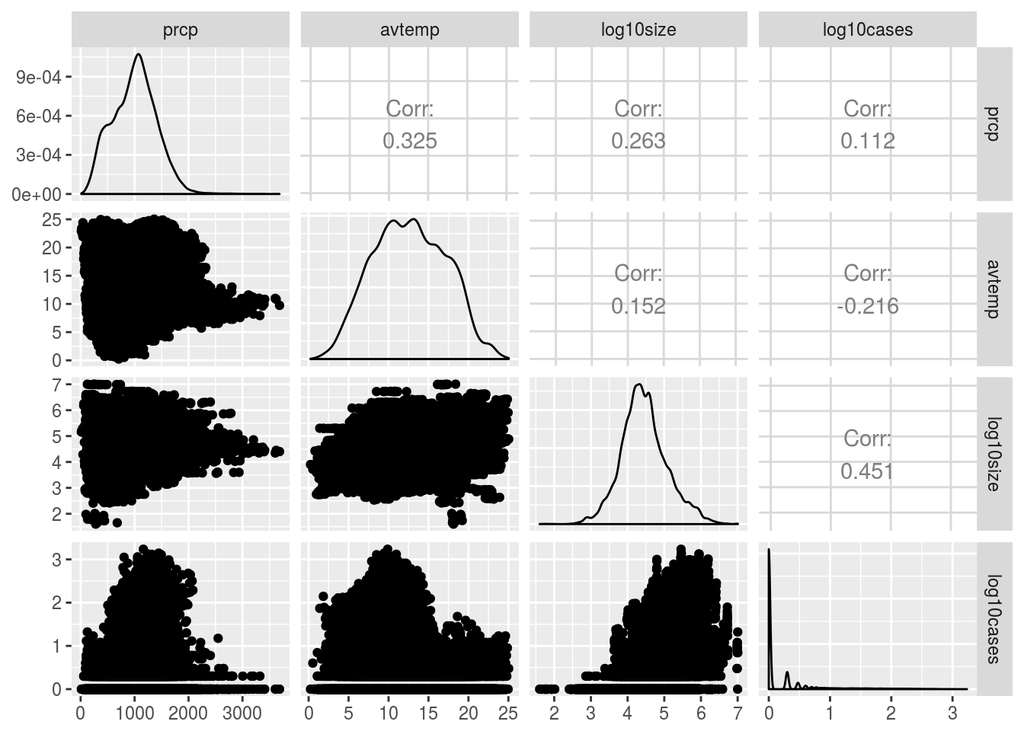

```r
ld.prism.pop %<>% mutate(log10size=log10(size))
ld.prism.pop %<>% mutate(log10cases=log10(cases+1))
ggpairs(ld.prism.pop,columns=c("prcp","avtemp","log10size","log10cases"))
```

## A simple linear model

Our `ggpairs` plot suggests that precipitation and average temperature are positively correlated with each other (perhaps not too surprising). Let’s look at that for a random subset of the data (it’s a bit easier to see that pattern when the data are thinned out).

*Task 4: Using `set.seed(222)` for reproducibility, create a new data frame to be a random sample (n=100 rows) of the full data frame and plot precipitation (x-axis) vs average temperature (y-axis).*

Hint: you can make use of the dplyr function `sample_n`. Hint: name your ggplot (“myPlot <- ggplot….”) then call it (plot it) on a separate line (this will make it easy to add a layer to the plot)

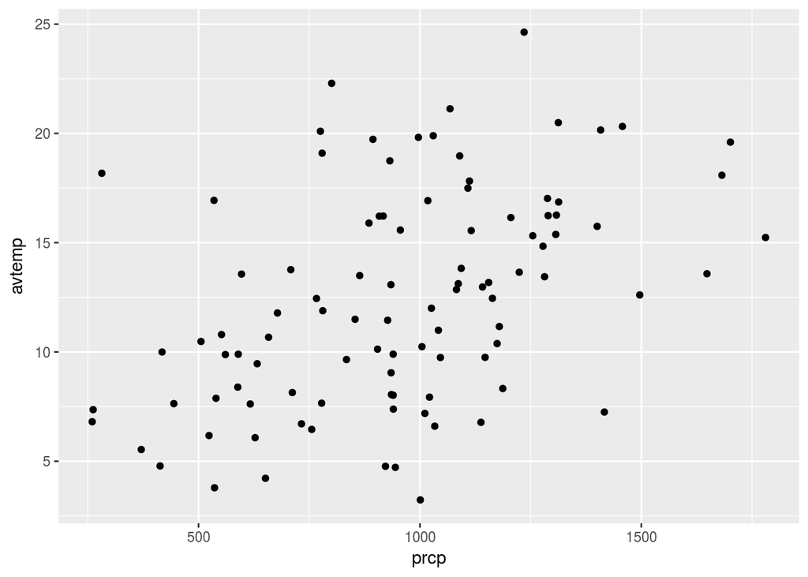

```r
# SOLUTION
set.seed(222)
smallData <- ld.prism.pop %>% sample_n(100)
plotSmall <- ggplot(smallData,aes(x=prcp,y=avtemp))+geom_point()
plotSmall
```

*Task 5: Add the best straight line to the plot using `geom_smooth`.*

Hint: You’ll need to use the appropriate method which you can find in the help file (?geom_smooth)

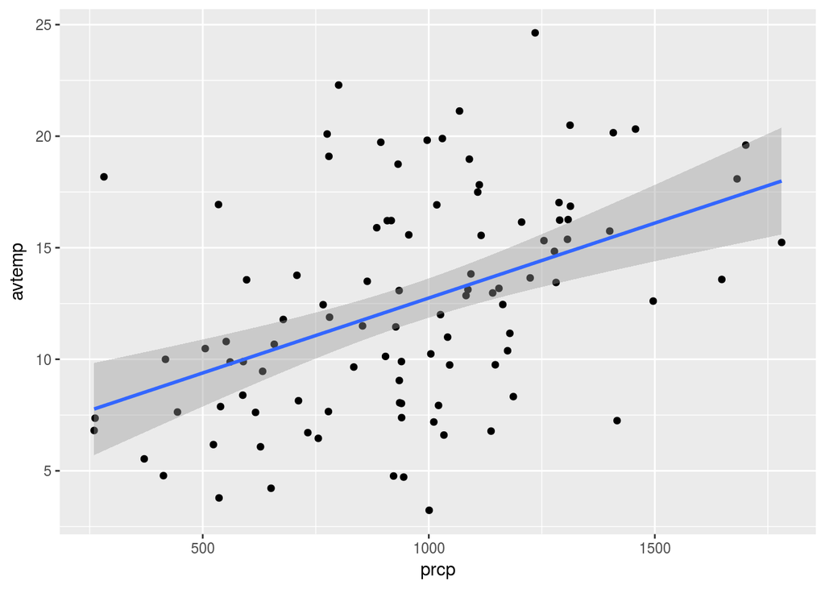

```r
# SOLUTION
plotSmall + geom_smooth(method="lm")
```

Further, we can store the linear model in memory and get a summary.

*Task 6: Create a linear model (lm) object with a call like “myModel <- lm(y ~ x, data = myData)” for the subsetted data, where y=avtemp and x=prcp. In addition, view the summary with a call along the lines of “summary(myModel)*

```r
# SOLUTION
lm_prcp_avtemp <- lm(avtemp ~ prcp, data = smallData)
summary(lm_prcp_avtemp)
```

```
##
## Call:
## lm(formula = avtemp ~ prcp, data = smallData)
##
## Residuals:
##     Min      1Q  Median      3Q     Max
## -9.5195 -3.2711 -0.3451  2.1937 10.8865
##
## Coefficients:
##             Estimate Std. Error t value Pr(>|t|)
## (Intercept)  6.02541    1.36916   4.401 2.75e-05 ***
## prcp         0.00672    0.00136   4.942 3.19e-06 ***
## ---
## Signif. codes:  0 '***' 0.001 '**' 0.01 '*' 0.05 '.' 0.1 ' ' 1
##
## Residual standard error: 4.397 on 98 degrees of freedom
## Multiple R-squared:  0.1995, Adjusted R-squared:  0.1913
## F-statistic: 24.42 on 1 and 98 DF,  p-value: 3.19e-06
```

We can extract information from this model object. For example, if your model object was actually called “myModel” (maybe not the best name; what happens if you have another model?) we can access the slope with `summary(myModel)$coefficients[2,1]` and the associated p-value with `summary(myModel)$coefficients[2,4]`

*Task 7: What is the slope of the line fitted during Task 5, and is the slope significantly different from 0 (p<0.05)?*

```r
# SOLUTION
summary(lm_prcp_avtemp)$coefficients[2,c(1,4)]
```

```
##     Estimate     Pr(>|t|)
## 6.720321e-03 3.190341e-06
```

## The `modelr` package

The `modelr` package is essentially a set of functions for modeling that are designed to help you seamlessly integrate modeling into a pipeline of data manipulation and visualization.

We’ll start with an illustration. We know the size of the US population has been growing.

*Task 8: Write a single line of code to generate a ggplot of total population size by year.*

Hint: you should pass the main (large) data frame to a “group_by” call and then a “summarize” call, then you can pass this new, unnamed data frame to ggplot using “ggplot(.)” and specifiy the aesthetics in a “geom_point” call.

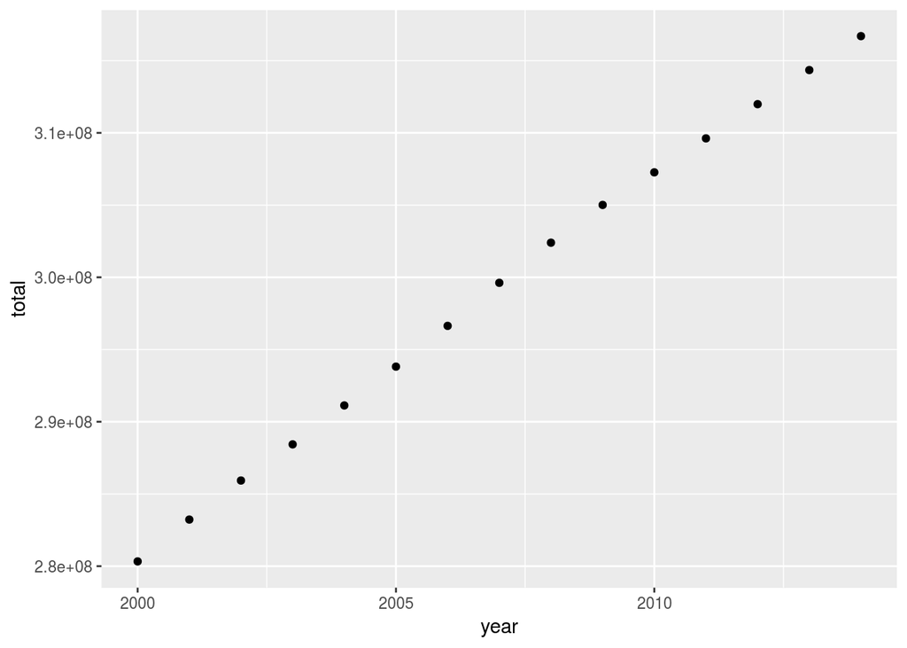

```r
# SOLUTION
ld.prism.pop %>% group_by(year) %>% summarize(total=sum(size)) %>% ggplot(.)+geom_point(aes(x=year,y=total))
```

While there is no doubt the population has been growing in recent years, it’s not clear if all states are contributing equally to this growth. Manipulating data to explore this has the potential to get quite cumbersome, but the `modelr` tools are designed to make this kind of hypothesis generation fairly painless.

### Grouped data frames versus nested data frames

We’re going to create a nested data frame, which we do by first creating a grouped data frame (which you’ve already done in another context).

*Task 9: Create a data frame called “by_state” from the main data frame, that groups by state, and inspect it.*

```r
# SOLUTION
by_state <- ld.prism.pop %>% group_by(state)
by_state
```

```
## Source: local data frame [46,630 x 11]
## Groups: state [49]
##
##      state          county cases  year  fips      prcp   avtemp str_year
##      <chr>           <chr> <int> <dbl> <dbl>     <dbl>    <dbl>    <chr>
## 1  Alabama  Autauga County     0  2000  1001  959.2705 18.10083  pop2000
## 2  Alabama  Baldwin County     1  2000  1003 1019.4288 19.67102  pop2000
## 3  Alabama  Barbour County     0  2000  1005 1005.5299 18.07437  pop2000
## 4  Alabama     Bibb County     0  2000  1007  993.6975 17.41745  pop2000
## 5  Alabama   Blount County     0  2000  1009 1178.8186 16.34566  pop2000
## 6  Alabama  Bullock County     0  2000  1011 1068.4641 17.66638  pop2000
## 7  Alabama   Butler County     0  2000  1013 1019.1419 18.65225  pop2000
## 8  Alabama  Calhoun County     0  2000  1015 1004.1205 16.09575  pop2000
## 9  Alabama Chambers County     0  2000  1017 1042.9926 16.42727  pop2000
## 10 Alabama Cherokee County     0  2000  1019 1146.2874 15.55200  pop2000
## # ... with 46,620 more rows, and 3 more variables: size <int>,
## #   log10size <dbl>, log10cases <dbl>
```

*Task 10: Next, update this new data frame so that it is nested (simply pass it to “nest”). Again, inspect the data frame by typing its name in the console so see how things changed.*

```r
# SOLUTION
by_state %<>% nest
by_state
```

```
## # A tibble: 49 × 2
##                   state                  data
##                   <chr>                <list>
## 1               Alabama <tibble [1,005 × 10]>
## 2               Arizona   <tibble [225 × 10]>
## 3              Arkansas <tibble [1,125 × 10]>
## 4            California   <tibble [870 × 10]>
## 5              Colorado   <tibble [960 × 10]>
## 6           Connecticut   <tibble [120 × 10]>
## 7              Delaware    <tibble [45 × 10]>
## 8  District of Columbia    <tibble [15 × 10]>
## 9               Florida <tibble [1,005 × 10]>
## 10              Georgia <tibble [2,385 × 10]>
## # ... with 39 more rows
```

You should see that by_state has a list-column called “data”. List elements are accessed with [[]]. For example to see the data for Georgia, the 10th state in the alphabetacized data frame, we would type “by_state$data[[10]]” in the console.

*Task 11: Display the Georgia data in the console window.*

```r
# SOLUTION
by_state$data[[10]]
```

```
## # A tibble: 2,385 × 10
##             county cases  year  fips      prcp   avtemp str_year  size
##              <chr> <int> <dbl> <dbl>     <dbl>    <dbl>    <chr> <int>
## 1   Appling County     0  2000 13001  965.4380 18.57411  pop2000 17408
## 2  Atkinson County     0  2000 13003 1055.4994 18.67689  pop2000  7610
## 3     Bacon County     0  2000 13005 1054.4589 18.75110  pop2000 10122
## 4     Baker County     0  2000 13007  962.7015 18.91609  pop2000  4053
## 5   Baldwin County     0  2000 13009  865.6932 17.32009  pop2000 44738
## 6     Banks County     0  2000 13011  993.0463 15.60285  pop2000 14504
## 7    Barrow County     0  2000 13013  978.6630 15.91831  pop2000 46561
## 8    Bartow County     0  2000 13015 1104.3244 15.55237  pop2000 76703
## 9  Ben Hill County     0  2000 13017 1102.0005 18.41798  pop2000 17473
## 10  Berrien County     0  2000 13019 1083.4106 18.70203  pop2000 16250
## # ... with 2,375 more rows, and 2 more variables: log10size <dbl>,
## #   log10cases <dbl>
```

Hopefully you noticed that this particular element of the data frame is itself a dataframe! The containing column, which contains several such data frames differing in length due to the number of counties per state, is most usefully organized as a list - hence the column-list format. This method of organizing data comes in very useful for exploratory modeling, as we’ll see. First we’re going to create another function.

*Task 12: Write a function that takes a data frame as its argument and returns a linear model object that predicts size by year.*

```r
# SOLUTION
linGrowth_model <- function(df){
  lm(size ~ year, data = df)
}
```

Next, we’re intorduced to one of the functions of `purrr`. This is a package that is installed as part of the `tidyverse`. When we use its functions - we need to make sure we have activeated the library. The function we’re interested in is called “map”. To illustrate its potential, we can immediately apply a state-wise statistical modeling exercise:

```r
library(purrr)
models<-map(by_state$data, linGrowth_model)
```

However, it makes sense to put the model object for each state with the appropriate state.

*Task 13: Add a column to the “by_state” dataframe, where each row (state) has its own model object.*

```r
# SOLUTION
by_state %<>% mutate(model = map(data, linGrowth_model))
```

In this format, we can, for example, store the residuals for each model (the discrepancy between the model prediction and the actual data). For this we will use the associated function to `map`, called `map2`, which takes 2 arguments and creates new data from them (in this case residuals).

```r
library(modelr)
by_state %<>% mutate(resids = map2(data, model, add_residuals))
```

In addition, we can visualize the slope of population growth by state.

*Task 14: Write a function that accepts a linear model and returns the slope (model M has slope M$coefficients[2]) and use this function to create a new column called “slope” in the “by_state” data frame, that is the slope for each state.*

```r
# SOLUTION
get_slope <- function(model){
  model$coefficients[2]
}
by_state %<>% mutate(slope = map(model, get_slope))
```

While we’re doing a great job at keeping our data organized, we’ve created another list-column (“slope” in data frame “by_state”). For visualization we’re going to want to un-nest this data structure…

```r
slopes <- unnest(by_state,slope)
```

Now we can pass this new data frame to ggplot to see how the growth rate manifested in different states.

*Task 15: Plot the growth rate (slope) for all states.*

Hint: If the states (x-axis) are hard to read, we can rotate them to be vertical by adding “+theme(axis.text.x = element_text(angle = 90, hjust = 1))” to the ggplot layers.

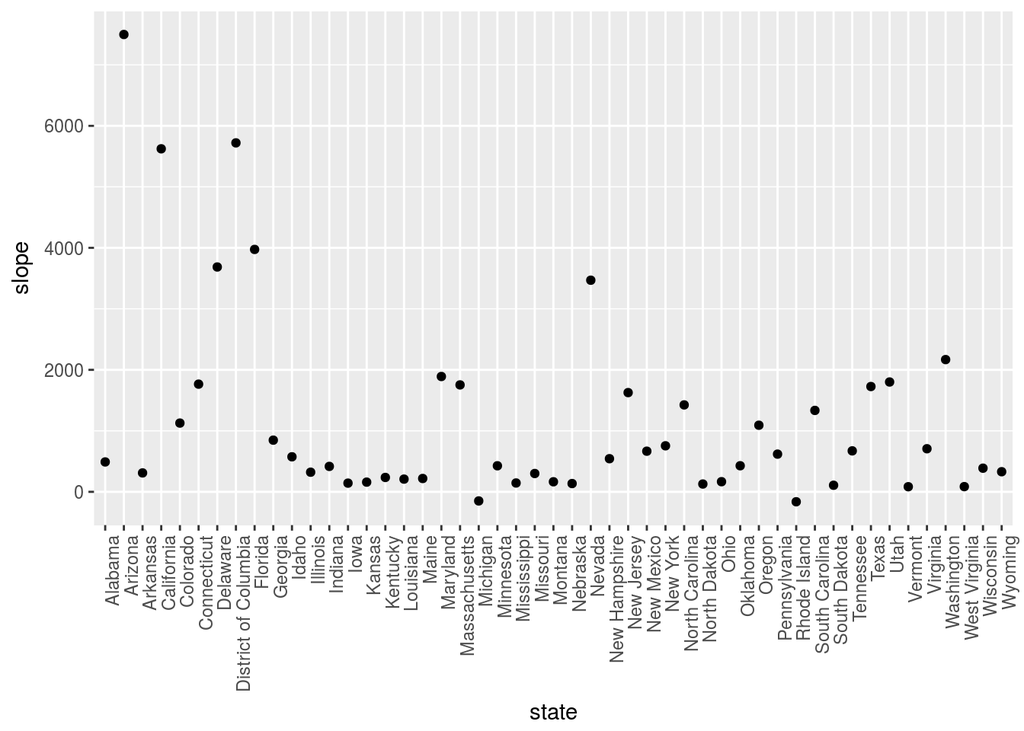

```r
# SOLUTION
slopes %>% ggplot(aes(state,slope))+geom_point()+theme(axis.text.x = element_text(angle = 90, hjust = 1))
```

What about the spatial pattern?

```r
library(ggmap)
library(maps)
#get map data for US counties and states
county_map <- map_data("county")
state_map <- map_data("state")

ag.fips <- group_by(ld.prism,fips)
ld.16y<-summarize(ag.fips,all.cases=sum(cases))
ld.16y<-left_join(select(ld.prism,c(state,county,fips)),ld.16y)
ld.16y<-distinct(ld.16y)
ld.16y %<>% rename(region=state,subregion=county)
ld.16y$subregion<-gsub(" County","",ld.16y$subregion)
ld.16y$region<-tolower(ld.16y$region)
ld.16y$subregion<-tolower(ld.16y$subregion)
ld.16y %<>% mutate(log10cases=log10(1+all.cases))

map.ld.16y<-left_join(county_map,ld.16y)

ggplot(map.ld.16y)+geom_point(aes(long,lat,color=log10cases),size=0.1)+scale_colour_gradientn(colours=rev(rainbow(4)))
```

[output not shown]